# R Notebook

load in libraries ##########

```r
library(tidyverse)
library(janitor)
library(ggfortify)
library(GGally)
library(modelr)
```

load in data ##########

```r
house <- read_csv("data/kc_house_data.csv")
```

task 1 #########

You might like to think about removing some or all of `date`, `id`, `sqft_living15`, `sqft_lot15` and `zipcode` (`lat` and `long` provide a better measure of location in any event). * Have a think about how to treat `waterfront`. Should we convert its type? * We converted `yr_renovated` into a `renovated` logical variable, indicating whether the property had ever been renovated. You may wish to do the same. * Have a think about how to treat `view`, `condition` and `grade`? Are they interval or categorical ordinal data types?

| price | bedrooms | bathrooms | sqft_living | sqft_lot | floors | waterfront | view | condition | grade | sqft_above | sqft_basement | yr_built | lat | long | renovated |
| --- | --- | --- | --- | --- | --- | --- | --- | --- | --- | --- | --- | --- | --- | --- | --- |
| 221900 | 3 | 1.00 | 1180 | 5650 | 1.0 | 0 | 0 | 3 | 7 | 1180 | 0 | 1955 | 47.5112 | -122.257 | 0 |
| 538000 | 3 | 2.25 | 2570 | 7242 | 2.0 | 0 | 0 | 3 | 7 | 2170 | 400 | 1951 | 47.7210 | -122.319 | 1 |
| 180000 | 2 | 1.00 | 770 | 10000 | 1.0 | 0 | 0 | 3 | 6 | 770 | 0 | 1933 | 47.7379 | -122.233 | 0 |
| 604000 | 4 | 3.00 | 1960 | 5000 | 1.0 | 0 | 0 | 5 | 7 | 1050 | 910 | 1965 | 47.5208 | -122.393 | 0 |
| 510000 | 3 | 2.00 | 1680 | 8080 | 1.0 | 0 | 0 | 3 | 8 | 1680 | 0 | 1987 | 47.6168 | -122.045 | 0 |
| 1225000 | 4 | 4.50 | 5420 | 101930 | 1.0 | 0 | 0 | 3 | 11 | 3890 | 1530 | 2001 | 47.6561 | -122.005 | 0 |
| 257500 | 3 | 2.25 | 1715 | 6819 | 2.0 | 0 | 0 | 3 | 7 | 1715 | 0 | 1995 | 47.3097 | -122.327 | 0 |
| 291850 | 3 | 1.50 | 1060 | 9711 | 1.0 | 0 | 0 | 3 | 7 | 1060 | 0 | 1963 | 47.4095 | -122.315 | 0 |
| 229500 | 3 | 1.00 | 1780 | 7470 | 1.0 | 0 | 0 | 3 | 7 | 1050 | 730 | 1960 | 47.5123 | -122.337 | 0 |
| 323000 | 3 | 2.50 | 1890 | 6560 | 2.0 | 0 | 0 | 3 | 7 | 1890 | 0 | 2003 | 47.3684 | -122.031 | 0 |

[output cut: 990 more lines]

| price | bedrooms | bathrooms | sqft_living | sqft_lot | floors | waterfront | yr_built | lat | long | renovated | grade_scale | view_scale | condition_scale |
| --- | --- | --- | --- | --- | --- | --- | --- | --- | --- | --- | --- | --- | --- |
| 221900 | 3 | 1.00 | 1180 | 5650 | 1.0 | not overlooking | 1955 | 47.5112 | -122.257 | 0 | Average | no view | Average |
| 538000 | 3 | 2.25 | 2570 | 7242 | 2.0 | not overlooking | 1951 | 47.7210 | -122.319 | 1 | Average | no view | Average |
| 180000 | 2 | 1.00 | 770 | 10000 | 1.0 | not overlooking | 1933 | 47.7379 | -122.233 | 0 | Low | no view | Average |
| 604000 | 4 | 3.00 | 1960 | 5000 | 1.0 | not overlooking | 1965 | 47.5208 | -122.393 | 0 | Average | no view | excellent |
| 510000 | 3 | 2.00 | 1680 | 8080 | 1.0 | not overlooking | 1987 | 47.6168 | -122.045 | 0 | Medium | no view | Average |
| 1225000 | 4 | 4.50 | 5420 | 101930 | 1.0 | not overlooking | 2001 | 47.6561 | -122.005 | 0 | High | no view | Average |
| 257500 | 3 | 2.25 | 1715 | 6819 | 2.0 | not overlooking | 1995 | 47.3097 | -122.327 | 0 | Average | no view | Average |
| 291850 | 3 | 1.50 | 1060 | 9711 | 1.0 | not overlooking | 1963 | 47.4095 | -122.315 | 0 | Average | no view | Average |
| 229500 | 3 | 1.00 | 1780 | 7470 | 1.0 | not overlooking | 1960 | 47.5123 | -122.337 | 0 | Average | no view | Average |
| 323000 | 3 | 2.50 | 1890 | 6560 | 2.0 | not overlooking | 2003 | 47.3684 | -122.031 | 0 | Average | no view | Average |

[output cut: 990 more lines]

```r
alias(lm(price ~ ., data = house_trim))

house_trim
```

no alias so can continue with the model

task 3 #########

```r
house_trim
```

```r
lm1 <- lm(price ~ sqft_living, data = house_trim)

summary(lm1)
```

signifcant coefficient

R^2 suggests the model explains 49.3% of variance in explaining price

```r
autoplot(lm1)
```

- residuals vs fitted - indicates population sample is independent
- normal q-q - skewed towards end of plot - suggests it plot is skewed
- scale-location - there is heteroskedasticity in the residuals indicated by positive gradient and shape of the distribution of points

# second model

```r
house_trim
```

```r
lm2 <- lm(price ~ sqft_living + bedrooms, data = house_trim)

summary(lm2)
```

```r
house_resid <- house_trim %>%
  add_residuals(lm2) %>%
  select(-c(price, sqft_living, bedrooms))


house_resid %>%
  select(resid, everything()) %>%
  ggpairs(aes(colour = waterfront, alpha = 0.5))
```

```r
# house_trim_numeric <- house_trim %>%
#   select_if(is.numeric)
#
# house_trim_nonnumeric <- house_trim %>%
#   select_if(function(x) !is.numeric(x))
#
# house_trim_nonnumeric$price <- house_trim$price
#
# ggpairs(house_trim_numeric)
# ggpairs(house_trim_nonnumeric)
```

residuals check

```r
house_resid_numeric <- house_resid %>%
  select_if(is.numeric)

house_resid_nonnumeric <- house_resid %>%
  select_if(function(x) !is.numeric(x))

house_resid_nonnumeric$price <- house_trim$price

ggpairs(house_resid_numeric)
ggpairs(house_resid_nonnumeric)
```

## add categorical variable

```r
summary(lm3)
```

```
Call:
lm(formula = price ~ sqft_living + bedrooms + waterfront, data = house_trim)

Residuals:
     Min       1Q   Median       3Q      Max
-1533354  -140023   -20490   103184  4286747

Coefficients:
                        Estimate Std. Error t value Pr(>|t|)
(Intercept)            73775.119   6371.911   11.58   <2e-16 ***
sqft_living              301.888      2.274  132.74   <2e-16 ***
bedrooms              -49712.475   2233.780  -22.25   <2e-16 ***
waterfrontoverlooking 794083.992  19724.796   40.26   <2e-16 ***
---
Signif. codes:  0 ‘***’ 0.001 ‘**’ 0.01 ‘*’ 0.05 ‘.’ 0.1 ‘ ’ 1

Residual standard error: 248700 on 21609 degrees of freedom
Multiple R-squared:  0.5412,    Adjusted R-squared:  0.5411
F-statistic:  8497 on 3 and 21609 DF,  p-value: < 2.2e-16
```

# dont need to do this because waterfront is already statistically significant

```r
anova(lm2, lm3)
```

```
Analysis of Variance Table

Model 1: price ~ sqft_living + bedrooms
Model 2: price ~ sqft_living + bedrooms + waterfront
  Res.Df        RSS Df  Sum of Sq      F    Pr(>F)
1  21610 1.4366e+15
2  21609 1.3364e+15  1 1.0023e+14 1620.7 < 2.2e-16 ***
---
Signif. codes:  0 ‘***’ 0.001 ‘**’ 0.01 ‘*’ 0.05 ‘.’ 0.1 ‘ ’ 1
```

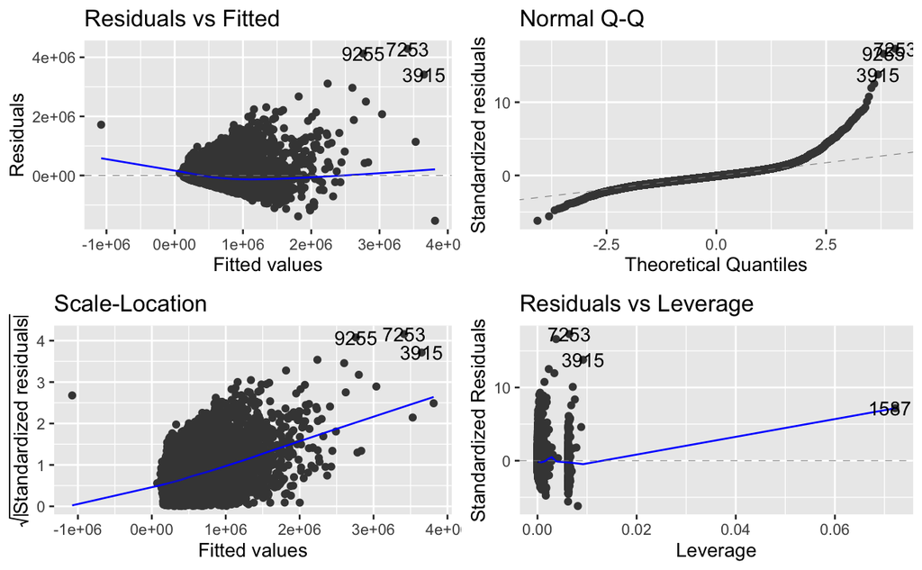

Not significant difference in any of the graphs but R^2 is better so variables are aiding in explanation of variance in residuals

residual check

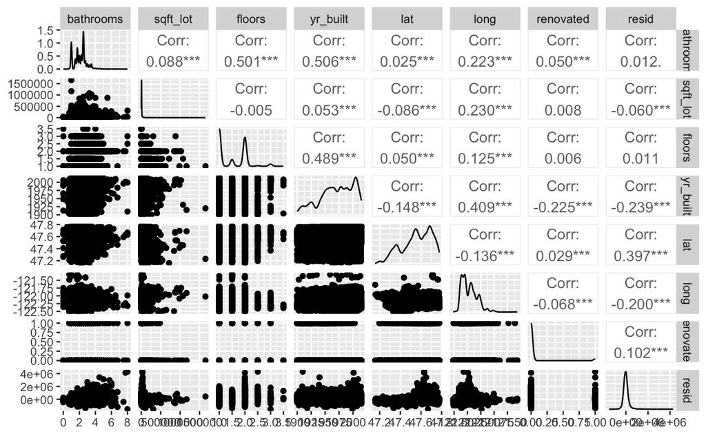

```r
house_resid_numeric <- house_resid %>%
  select_if(is.numeric)

house_resid_nonnumeric <- house_resid %>%
  select_if(function(x) !is.numeric(x))

house_resid_nonnumeric$price <- house_trim$price

ggpairs(house_resid_numeric)
```

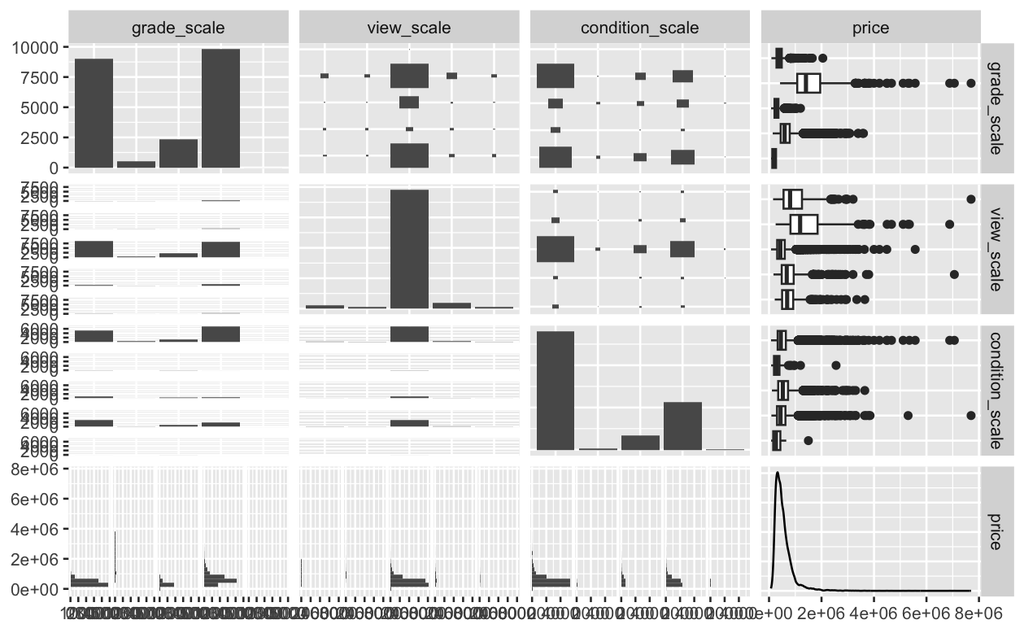

```r
ggpairs(house_resid_nonnumeric)
```

correlations of note

- lat and long
- yr_built
- view scale - looks relevant
- price needs a log transform - data is heavily skewed to the right

```r
summary(lm4)
```

```
Call:
lm(formula = price ~ sqft_living + bedrooms + waterfront + view_scale,
    data = house_trim)

Residuals:
     Min       1Q   Median       3Q      Max
-1719899  -134604   -18903   102186  4290464

Coefficients:
                        Estimate Std. Error t value Pr(>|t|)
(Intercept)            2.616e+05  1.286e+04  20.334  < 2e-16 ***
sqft_living            2.832e+02  2.308e+00 122.728  < 2e-16 ***
bedrooms              -4.419e+04  2.192e+03 -20.157  < 2e-16 ***
waterfrontoverlooking  4.747e+05  2.375e+04  19.988  < 2e-16 ***
view_scalegood view    2.125e+05  1.964e+04  10.818  < 2e-16 ***
view_scaleno view     -1.830e+05  1.113e+04 -16.439  < 2e-16 ***
view_scalepoor view   -6.768e+04  1.336e+04  -5.066 4.09e-07 ***
view_scaleslight view -2.211e+04  1.720e+04  -1.286    0.199
---
Signif. codes:  0 ‘***’ 0.001 ‘**’ 0.01 ‘*’ 0.05 ‘.’ 0.1 ‘ ’ 1

Residual standard error: 243200 on 21605 degrees of freedom
Multiple R-squared:  0.5612,    Adjusted R-squared:  0.561
F-statistic:  3947 on 7 and 21605 DF,  p-value: < 2.2e-16
```

```r
anova(lm3,lm4)
```

```
Analysis of Variance Table

Model 1: price ~ sqft_living + bedrooms + waterfront
Model 2: price ~ sqft_living + bedrooms + waterfront + view_scale
  Res.Df        RSS Df  Sum of Sq      F    Pr(>F)
1  21609 1.3364e+15
2  21605 1.2782e+15  4 5.8179e+13 245.84 < 2.2e-16 ***
---
Signif. codes:  0 ‘***’ 0.001 ‘**’ 0.01 ‘*’ 0.05 ‘.’ 0.1 ‘ ’ 1
```

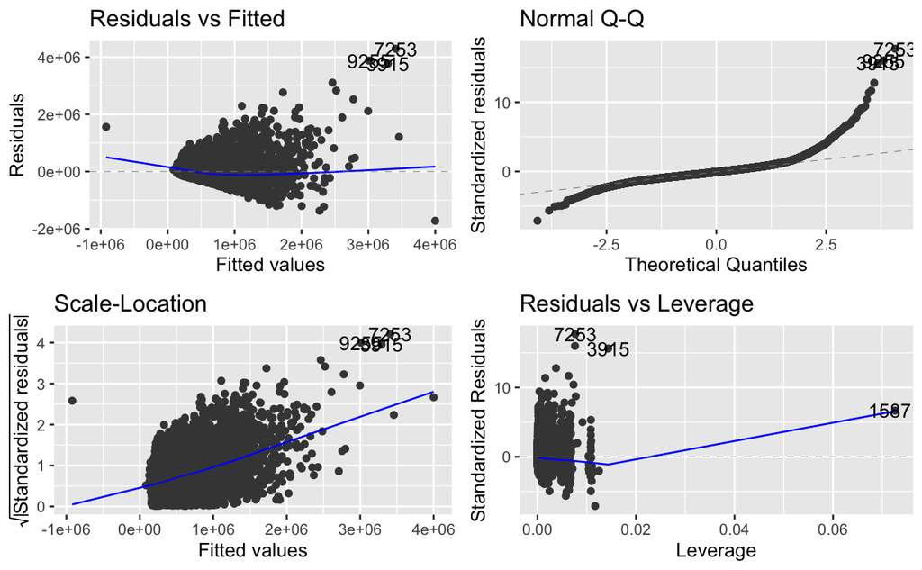

# will perform log transformation

```r
lm5 <- lm(log(price) ~ sqft_living + bedrooms + waterfront + view_scale, data = house_trim)

summary(lm5)
```

reduces R^2

will remove view_scale and replace with yr_built

[output not shown]

[output cut: 990 more lines]

```r
summary(lm5)
```

[output not shown]

```r
# residuals

house_resid <- house_trim %>%
  add_residuals(lm3) %>%
  select(-c(price, sqft_living, bedrooms, waterfront))
```

```r
house_resid_numeric <- house_resid %>%
  select_if(is.numeric)

house_resid_nonnumeric <- house_resid %>%
  select_if(function(x) !is.numeric(x))

house_resid_nonnumeric$price <- house_trim$price

ggpairs(house_resid_numeric)
ggpairs(house_resid_nonnumeric)
```

# extension

```r
summary(lm5)
```

```
Call:
lm(formula = price ~ sqft_living + bedrooms + waterfront + yr_built,
    data = house_trim)

Residuals:
     Min       1Q   Median       3Q      Max
-1750670  -129123   -17263   103052  4000880

Coefficients:
                        Estimate Std. Error t value Pr(>|t|)
(Intercept)            4.495e+06  1.153e+05   38.99   <2e-16 ***
sqft_living            3.275e+02  2.299e+00  142.44   <2e-16 ***
bedrooms              -5.329e+04  2.163e+03  -24.64   <2e-16 ***
waterfrontoverlooking  7.455e+05  1.913e+04   38.98   <2e-16 ***
yr_built              -2.264e+03  5.894e+01  -38.41   <2e-16 ***
---
Signif. codes:  0 ‘***’ 0.001 ‘**’ 0.01 ‘*’ 0.05 ‘.’ 0.1 ‘ ’ 1

Residual standard error: 240600 on 21608 degrees of freedom
Multiple R-squared:  0.5705,    Adjusted R-squared:  0.5705
F-statistic:  7176 on 4 and 21608 DF,  p-value: < 2.2e-16
```

interaction:would probably choose, given bedrooms, what impact does sqft_living have on price?

```r
summary(lm6)
```

```
Call:
lm(formula = price ~ sqft_living + lat + view_scale + grade_scale +
    lat:grade_scale, data = house_trim)

Residuals:
     Min       1Q   Median       3Q      Max
-1758276   -99421   -16183    68816  4389118

Coefficients:
                          Estimate Std. Error t value Pr(>|t|)
(Intercept)             -2.768e+07  7.321e+05 -37.806  < 2e-16 ***
sqft_living              2.009e+02  2.235e+00  89.911  < 2e-16 ***
lat                      5.877e+05  1.539e+04  38.172  < 2e-16 ***
view_scalegood view      3.613e+05  1.543e+04  23.411  < 2e-16 ***
view_scaleno view       -2.131e+05  9.841e+03 -21.651  < 2e-16 ***
view_scalepoor view     -9.777e+04  1.184e+04  -8.260  < 2e-16 ***
view_scaleslight view   -6.097e+04  1.524e+04  -4.000 6.35e-05 ***
grade_scaleHigh         -5.581e+07  5.467e+06 -10.209  < 2e-16 ***
grade_scaleLow           5.918e+06  1.777e+06   3.331 0.000868 ***
grade_scaleMedium       -1.267e+07  1.075e+06 -11.785  < 2e-16 ***
grade_scaleVery Low      1.973e+07  3.434e+07   0.575 0.565581
lat:grade_scaleHigh      1.184e+06  1.148e+05  10.309  < 2e-16 ***
lat:grade_scaleLow      -1.243e+05  3.738e+04  -3.324 0.000888 ***
lat:grade_scaleMedium    2.677e+05  2.261e+04  11.842  < 2e-16 ***
lat:grade_scaleVery Low -4.136e+05  7.246e+05  -0.571 0.568146
---
Signif. codes:  0 ‘***’ 0.001 ‘**’ 0.01 ‘*’ 0.05 ‘.’ 0.1 ‘ ’ 1

Residual standard error: 215700 on 21598 degrees of freedom
Multiple R-squared:  0.6549,    Adjusted R-squared:  0.6546
F-statistic:  2927 on 14 and 21598 DF,  p-value: < 2.2e-16
```

```r
summary(lm7)
```

```
Call:
lm(formula = log(price) ~ sqft_living + lat + view_scale + grade_scale +
    sqft_living:view_scale, data = house_trim)

Residuals:
     Min       1Q   Median       3Q      Max
-1.49868 -0.17788 -0.00933  0.16624  1.23430

Coefficients:
                                    Estimate Std. Error t value Pr(>|t|)
(Intercept)                       -5.923e+01  6.616e-01 -89.524  < 2e-16 ***
sqft_living                        2.251e-04  1.060e-05  21.225  < 2e-16 ***
lat                                1.515e+00  1.391e-02 108.902  < 2e-16 ***
view_scalegood view                4.235e-01  5.043e-02   8.398  < 2e-16 ***
view_scaleno view                 -4.432e-01  3.437e-02 -12.897  < 2e-16 ***
view_scalepoor view               -1.251e-01  4.086e-02  -3.062 0.002201 **
view_scaleslight view             -1.562e-01  5.328e-02  -2.932 0.003368 **
grade_scaleHigh                    4.178e-01  1.574e-02  26.543  < 2e-16 ***
grade_scaleLow                    -1.370e-01  6.765e-03 -20.246  < 2e-16 ***
grade_scaleMedium                  1.845e-01  4.799e-03  38.435  < 2e-16 ***
grade_scaleVery Low               -2.091e-01  1.408e-01  -1.485 0.137459
sqft_living:view_scalegood view   -5.265e-05  1.452e-05  -3.626 0.000289 ***
sqft_living:view_scaleno view      5.731e-05  1.076e-05   5.325 1.02e-07 ***
sqft_living:view_scalepoor view    6.259e-06  1.310e-05   0.478 0.632777
sqft_living:view_scaleslight view  3.148e-05  1.814e-05   1.735 0.082782 .
---
Signif. codes:  0 ‘***’ 0.001 ‘**’ 0.01 ‘*’ 0.05 ‘.’ 0.1 ‘ ’ 1

Residual standard error: 0.2814 on 21598 degrees of freedom
Multiple R-squared:  0.7147,    Adjusted R-squared:  0.7146
F-statistic:  3866 on 14 and 21598 DF,  p-value: < 2.2e-16
```

```r
house_resid <- house_trim %>%
  add_residuals(lm7)


coplot(resid ~ sqft_living | view_scale,
       panel = function(x, y, ...){
         points(x, y)
         abline(lm(y ~ x), col = "blue")
       },
       data = house_resid, rows = 1)
```

[figure not shown]

```r
# because I categorised some variables, lost some information so model doesn't
# explain the variance as well as it could

model <- lm(log(price) ~ ., data = house_trim)

summary(model)
```

```r
houses_tidy <- houses %>%
  select(-c("id", "date", "sqft_living15", "sqft_lot15", "zipcode")) %>%
  mutate(waterfront = as.logical(waterfront)) %>%
  mutate(renovated = yr_renovated != 0) %>%
  select(-"yr_renovated") %>%
  mutate(view = as_factor(view)) %>%
  mutate(condition = as_factor(condition)) %>%
  mutate(grade = as_factor(grade))
```

```
Error in select(., -c("id", "date", "sqft_living15", "sqft_lot15", "zipcode")) :
  object 'houses' not found
```

```r
summary(lm8)
```

```
Call:
lm(formula = log(price) ~ sqft_living + lat + view + grade +
    sqft_living:view, data = houses_tidy)

Residuals:
     Min       1Q   Median       3Q      Max
-1.47858 -0.17370 -0.01097  0.16373  1.16992

Coefficients:
                    Estimate Std. Error t value Pr(>|t|)
(Intercept)       -5.878e+01  7.012e-01 -83.822  < 2e-16 ***
sqft_living        2.304e-04  3.396e-06  67.831  < 2e-16 ***
lat                1.485e+00  1.358e-02 109.354  < 2e-16 ***
view1              2.925e-01  4.059e-02   7.205 6.01e-13 ***
view2              3.251e-01  2.330e-02  13.954  < 2e-16 ***
view3              4.413e-01  3.368e-02  13.101  < 2e-16 ***
view4              8.130e-01  3.783e-02  21.491  < 2e-16 ***
grade3             4.385e-01  3.165e-01   1.385 0.165954
grade4             2.535e-01  2.788e-01   0.909 0.363284
grade5             3.240e-01  2.747e-01   1.180 0.238122
grade6             4.554e-01  2.742e-01   1.661 0.096764 .
grade7             6.040e-01  2.742e-01   2.203 0.027584 *
grade8             7.558e-01  2.742e-01   2.756 0.005848 **
grade9             9.198e-01  2.743e-01   3.354 0.000799 ***
grade10            1.049e+00  2.744e-01   3.823 0.000132 ***
grade11            1.153e+00  2.748e-01   4.197 2.72e-05 ***
grade12            1.283e+00  2.762e-01   4.645 3.42e-06 ***
grade13            1.391e+00  2.857e-01   4.870 1.12e-06 ***
sqft_living:view1 -2.566e-05  1.473e-05  -1.742 0.081549 .
sqft_living:view2 -5.482e-05  8.250e-06  -6.645 3.11e-11 ***
sqft_living:view3 -6.189e-05  1.056e-05  -5.860 4.71e-09 ***
sqft_living:view4 -1.005e-04  1.060e-05  -9.485  < 2e-16 ***
---
Signif. codes:  0 ‘***’ 0.001 ‘**’ 0.01 ‘*’ 0.05 ‘.’ 0.1 ‘ ’ 1

Residual standard error: 0.2741 on 21591 degrees of freedom
Multiple R-squared:  0.7294,    Adjusted R-squared:  0.7292
F-statistic:  2772 on 21 and 21591 DF,  p-value: < 2.2e-16
```